# Student Depression Analysis Project

# Introduction

Depression is a growing concern, particularly among students and young professionals who often face significant academic, professional, and personal pressures. It is critical to identify individuals at risk early on to provide timely support and interventions. In this project we use data analysis and machine learning models to explore various factors potentially associated with depression, including academic pressure, sleep patterns, dietary habits, work-study hours, and demographic characteristics. By examining these factors, the aim is to understand the underlying relationships and identify patterns that can contribute to better mental health awareness and support systems.

### Purpose

The primary goal of this project is to identify key factors associated with depression among students and young professionals and to build predictive models that can accurately identify individuals at risk. By analyzing variables like academic pressure, sleep patterns, dietary habits, work hours, and demographic characteristics, we seek to determine which factors are most strongly related to depression risk. While the focus is on prediction rather than inference, this knowledge can be used to create early warning systems and design interventions to address mental health issues effectively.

### Measuring Effectiveness

In this project, recall is prioritized over precision as the primary evaluation metric. Recall measures the proportion of actual cases of depression that are correctly identified by the model. This is crucial because missing someone who is truly at risk of depression (a false negative) could lead to severe consequences, such as not receiving the help they urgently need. While false positives (classifying someone as depressed when they are not) are not desirable either, they are far less harmful compared to false negatives. By focusing on recall, in this project we aim to ensure that as many at-risk individuals as possible are correctly identified.

# Dataset

### Dataset Description

We are starting with loading the **Student Depression Dataset**, downloaded from the kaggle.com.

**Source**: [Kaggle - Student Depression Dataset](https://www.kaggle.com/datasets/adilshamim8/student-depression-dataset?resource=download)

```r
data <- read.csv("student_depression_dataset.csv")
str(data)
```

```
## 'data.frame':    27901 obs. of  18 variables:
##  $ id                                   : int  2 8 26 30 32 33 52 56 59 62 ...
##  $ Gender                               : chr  "Male" "Female" "Male" "Female" ...
##  $ Age                                  : num  33 24 31 28 25 29 30 30 28 31 ...
##  $ City                                 : chr  "Visakhapatnam" "Bangalore" "Srinagar" "Varanasi" ...
##  $ Profession                           : chr  "Student" "Student" "Student" "Student" ...
##  $ Academic.Pressure                    : num  5 2 3 3 4 2 3 2 3 2 ...
##  $ Work.Pressure                        : num  0 0 0 0 0 0 0 0 0 0 ...
##  $ CGPA                                 : num  8.97 5.9 7.03 5.59 8.13 5.7 9.54 8.04 9.79 8.38 ...
##  $ Study.Satisfaction                   : num  2 5 5 2 3 3 4 4 1 3 ...
##  $ Job.Satisfaction                     : num  0 0 0 0 0 0 0 0 0 0 ...
##  $ Sleep.Duration                       : chr  "'5-6 hours'" "'5-6 hours'" "'Less than 5 hours'" "'7-8 hours'" ...
##  $ Dietary.Habits                       : chr  "Healthy" "Moderate" "Healthy" "Moderate" ...
##  $ Degree                               : chr  "B.Pharm" "BSc" "BA" "BCA" ...
##  $ Have.you.ever.had.suicidal.thoughts..: chr  "Yes" "No" "No" "Yes" ...
##  $ Work.Study.Hours                     : num  3 3 9 4 1 4 1 0 12 2 ...
##  $ Financial.Stress                     : chr  "1.0" "2.0" "1.0" "5.0" ...
##  $ Family.History.of.Mental.Illness     : chr  "No" "Yes" "Yes" "Yes" ...
##  $ Depression                           : int  1 0 0 1 0 0 0 0 1 1 ...
```

This dataset comprises 27,901 observations and 18 variables, focusing on a study of mental health and depression, particularly among students. The target variable is **Depression**, which is binary (1 for depressed, 0 for not depressed), with the remaining variables serving as predictors. The numeric variables include Age, id, Academic.Pressure, Work.Pressure, CGPA, Study.Satisfaction, Job.Satisfaction, Work.Study.Hours, and Depression. Meanwhile, the categorical variables are Gender, City, Profession, Sleep.Duration, Dietary.Habits, Degree, Have.you.ever.had.suicidal.thoughts.., Financial.Stress, and Family.History.of.Mental.Illness.

### Data Cleaning

Now, we are going to look for any missing values present in our dataset.

```r
sum(is.na(data))
```

```
## [1] 0
```

```r
sum(data == "?")
```

```
## [1] 3
```

```r
sum(data$Financial.Stress == "?")
```

```
## [1] 3
```

The dataset contains a small number of missing values in the form of “?”. Specifically, there are three instances of “?” in the column **Financial.Stress**. Since this is a very small proportion of the dataset, these observations will be removed to ensure data quality.

The following code was used to remove these observations:

```r
data <- data[data$Financial.Stress != "?", ]
sum(data$Financial.Stress == "?")
```

```
## [1] 0
```

After this operation, the dataset no longer contains any missing values.

Now, we would like to continue with exploration of the non-zero values in the columns Work.Pressure and Job.Satisfaction, as they were found to contain small amount of the non-zero values during the manual dataset inspection.

```r
sum(data$Work.Pressure != 0)
```

```
## [1] 3
```

```r
sum(data$Job.Satisfaction != 0)
```

```
## [1] 8
```

```r
sum(data$Profession != "Student")
```

```
## [1] 31
```

The results show that the column **Work.Pressure** has only 3 non-zero values and **Job.Satisfaction** has only 8 non-zero values out of 27,901 observations. This indicates that the majority of values in these columns are zero. Similarly, the column **Profession** contains only 31 entries that are not categorized as ‘Student’. Since we are focusing solely on students, we will retain only the entries where ‘Profession’ is ‘Student’. As a result, the column Profession no longer holds any explanatory power and will be removed from the dataset.

Moreover, since the number of non-zero values in these columns is extremely low compared to the total dataset size, these variables are unlikely to provide meaningful insights. Therefore, we have decided to exclude **Work.Pressure** **Job.Satisfaction**, **Profession** from further analysis to focus on variables that contribute more significantly to our objectives.

```r
data$Work.Pressure <- NULL
data$Job.Satisfaction <- NULL
# We further remove rows where Profession is not "Student", as we are interested only in students
data <- data[data$Profession == "Student", ]
data$Profession <- NULL
dim(data)
```

```
## [1] 27867    15
```

The updated dataset, data, now consists of 27867 observations and 15 variables.

### Exploratory Data Analysis (EDA)

To begin with, we would like to use summary statistics of the dataset. This provides an overview of both numerical and categorical variables, helping us to identify any patterns at a glance.

```r
summary(data)
```

```
##        id            Gender               Age            City
##  Min.   :     2   Length:27867       Min.   :18.00   Length:27867
##  1st Qu.: 35057   Class :character   1st Qu.:21.00   Class :character
##  Median : 70659   Mode  :character   Median :25.00   Mode  :character
##  Mean   : 70440                      Mean   :25.82
##  3rd Qu.:105816                      3rd Qu.:30.00
##  Max.   :140699                      Max.   :59.00
##  Academic.Pressure      CGPA        Study.Satisfaction Sleep.Duration
##  Min.   :0.000     Min.   : 0.000   Min.   :0.000      Length:27867
##  1st Qu.:2.000     1st Qu.: 6.290   1st Qu.:2.000      Class :character
##  Median :3.000     Median : 7.770   Median :3.000      Mode  :character
##  Mean   :3.141     Mean   : 7.656   Mean   :2.944
##  3rd Qu.:4.000     3rd Qu.: 8.920   3rd Qu.:4.000
##  Max.   :5.000     Max.   :10.000   Max.   :5.000
##  Dietary.Habits        Degree          Have.you.ever.had.suicidal.thoughts..
##  Length:27867       Length:27867       Length:27867
##  Class :character   Class :character   Class :character
##  Mode  :character   Mode  :character   Mode  :character
##
##
##
##  Work.Study.Hours Financial.Stress   Family.History.of.Mental.Illness
##  Min.   : 0.000   Length:27867       Length:27867
##  1st Qu.: 4.000   Class :character   Class :character
##  Median : 8.000   Mode  :character   Mode  :character
##  Mean   : 7.158
##  3rd Qu.:10.000
##  Max.   :12.000
##    Depression
##  Min.   :0.0000
##  1st Qu.:0.0000
##  Median :1.0000
##  Mean   :0.5852
##  3rd Qu.:1.0000
##  Max.   :1.0000
```

From the summary statistics we can describe the variables:

1. **id**: A unique identifier for each observation, ranging from 2 to 140,699.
2. **Gender**: A categorical variable indicating the gender of individuals.
3. **Age**: A numeric variable ranging from 18 to 59 years, with a mean age of 25.82 years.
4. **City**: A categorical variable representing the city of residence.
5. **Academic.Pressure**: A numeric variable measuring academic pressure, with values ranging from 0 to 5 and a mean of 3.14.
6. **CGPA**: A numeric variable for cumulative grade point average, ranging from 0 to 10, with a mean of 7.66.
7. **Study.Satisfaction**: A numeric variable measuring satisfaction with studies, ranging from 0 to 5, with a mean of 2.94.
8. **Sleep.Duration**: A categorical variable representing sleep duration.
9. **Dietary.Habits**: A categorical variable capturing dietary habits.
10. **Degree**: A categorical variable indicating the degree pursued.
11. **Have.you.ever.had.suicidal.thoughts.**: A categorical variable asking whether individuals have ever had suicidal thoughts (“Yes”/“No”).
12. **Work.Study.Hours**: A numeric variable indicating the combined hours spent on work and study, ranging from 0 to 12, with a mean of 7.157 hours.
13. **Financial.Stress**: A categorical variable measuring the level of financial stress experienced by individuals.
14. **Family.History.of.Mental.Illness**: A categorical variable indicating the presence or absence of a family history of mental illness.
15. **Depression**: The binary target variable that indicates whether an individual is experiencing depression (1) or not (0).

### Correlation Matrix

Now, we would like to have a look at the correlation matrix, but to do that we first encode columns with “Yes”/“No” values as 1/0, so that we can include them too.

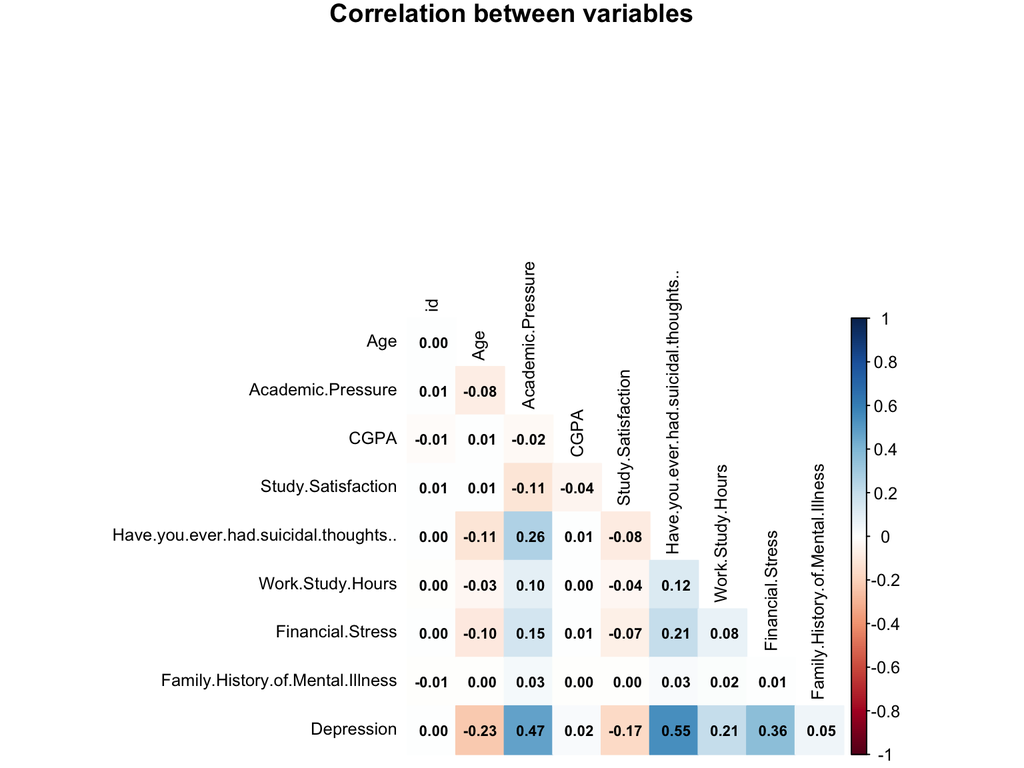

```r
# We create the new dataset for purpose of correlation matrix, as we do not
# want to alter the main one
data_encoded <- data

binary_columns <- c("Have.you.ever.had.suicidal.thoughts..",
                    "Family.History.of.Mental.Illness")
data_encoded[binary_columns] <- lapply(data_encoded[binary_columns],
                                       function(x) ifelse(x == "Yes", 1, 0))

numeric_columns <- c("id", "Financial.Stress")
data_encoded[numeric_columns] <- lapply(data_encoded[numeric_columns], as.numeric)

# Now we exclude all the categorical variables
data_encoded <- data_encoded[sapply(data_encoded, is.numeric)]

correlation_matrix <- cor(data_encoded, use = "pairwise.complete.obs")
correlation_matrix <- (correlation_matrix + t(correlation_matrix))/2

corrplot(correlation_matrix,
         method = "color",
         addCoef.col = 'black',
         type = "lower",
         diag = FALSE,
         number.cex = 0.7,
         tl.cex = 0.8,  # Text label size
         cl.cex = 0.8,
         tl.col = "black",
         cl.pos = "r",
         mar = c(0, 0, 1, 0),
         title = "Correlation between variables")
```

From the correlation plot we can observe the following:

Variable **Depression** is moderately positively correlated with Financial Stress (0.36), Have you ever had suicidal thoughts.. (0.55) and Academic Pressure (0.47), indicating these factors may contribute to higher depression levels. There is also a moderate-weak correlation with Work Study Hours (0.21). Additionally, variable Depression has a negative correlation with Study Satisfaction (-0.17) and Age (-0.23).

### Plots

Now, we would like to have a deeper look into main predictors of the depression and some additional variables.

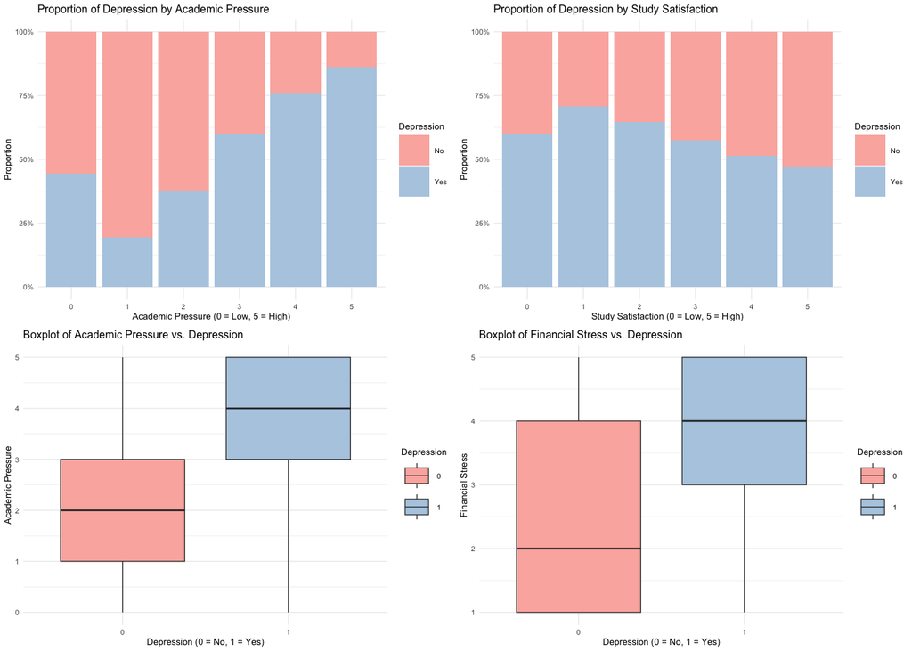

```r
p1 <- ggplot(data, aes(
  x = as.factor(Academic.Pressure),
  fill = factor(Depression, levels = c(0, 1), labels = c("No", "Yes"))
)) +
  geom_bar(position = "fill") +
  labs(
    title = "Proportion of Depression by Academic Pressure",
    x = "Academic Pressure (0 = Low, 5 = High)",
    y = "Proportion",
    fill = "Depression"
  ) +
  scale_y_continuous(labels = scales::percent) +
  scale_fill_brewer(palette = "Pastel1")+
  theme_minimal(base_size = 5)

p2 <- ggplot(data, aes(
  x = as.factor(Study.Satisfaction),
  fill = factor(Depression, levels = c(0, 1), labels = c("No", "Yes"))
)) +
  geom_bar(position = "fill") +
  labs(
    title = "Proportion of Depression by Study Satisfaction",
    x = "Study Satisfaction (0 = Low, 5 = High)",
    y = "Proportion",
    fill = "Depression"
  ) +
  scale_y_continuous(labels = scales::percent) +
  scale_fill_brewer(palette = "Pastel1") +
  theme_minimal(base_size = 5)

# Boxplot for Academic Pressure vs. Depression
brewer_colors <- brewer.pal(3, "Pastel1")
p3 <- ggplot(data, aes(x = as.factor(Depression), y = Academic.Pressure, fill = as.factor(Depression))) +
  geom_boxplot() +
  labs(
    title = "Boxplot of Academic Pressure vs. Depression",
    x = "Depression (0 = No, 1 = Yes)",
    y = "Academic Pressure",
    fill = "Depression"
  ) +
  scale_fill_manual(
    values = brewer_colors[1:2],  # Select 2 colors from Set 2
    labels = c("0", "1")  # Customize the legend labels here
  )+
  theme_minimal(base_size = 5)

# Boxplot for Financial Stress vs. Depression
p4 <- ggplot(data, aes(x = as.factor(Depression), y = as.numeric(Financial.Stress), fill = as.factor(Depression))) +
  geom_boxplot() +
  labs(
    title = "Boxplot of Financial Stress vs. Depression",
    x = "Depression (0 = No, 1 = Yes)",
    y = "Financial Stress",
    fill = "Depression"
  ) +
  scale_fill_manual(
    values = brewer_colors[1:2],  # Select 2 colors from Set 2
    labels = c("0", "1")  # Customize the legend labels here
  ) +
  theme_minimal(base_size = 5)



grid.arrange(p1, p2, p3, p4, ncol = 2)
```

#### Academic Pressure and Depression

1. Proportional Bar Chart: We can observe a clear upward trend in depression prevalence (blue bars) as academic pressure increases. Students experiencing higher academic pressure (levels 4 and 5) report higher rates of depression.
2. Boxplot: From a bit different type of visualisation, we can observe that students with depression report significantly higher academic pressure compared to those without.

#### Study Satisfaction and Depression

From the proportional bar chart we can observe that depression rates decline as study satisfaction increases. Students most satisfied with their studies (level 5) show the lowest prevalence of depression.

#### Financial Stress and Depression

From the boxplot we can see that students experiencing depression tend to report higher financial stress levels, suggesting a strong link between financial pressure and mental health challenges.

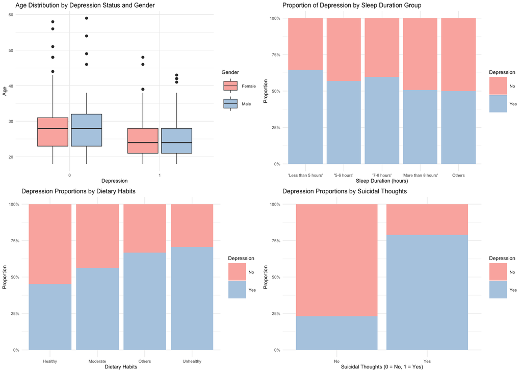

```r
p5 <- ggplot(data, aes(x = as.factor(Depression), y = Age, fill = Gender)) +
  geom_boxplot() +
  labs(title = "Age Distribution by Depression Status and Gender",
       x = "Depression",
       y = "Age") + scale_fill_brewer(palette = "Pastel1") +
  theme_minimal(base_size = 5)

sleep <- factor(
  data$Sleep.Duration,
  levels = c("'Less than 5 hours'", "'5-6 hours'", "'7-8 hours'", "'More than 8 hours'", "Others"))

p6 <- ggplot(data, aes(
  x = sleep,
  fill = factor(Depression, levels = c(0, 1), labels = c("No", "Yes"))
)) +
  geom_bar(position = "fill") +
  labs(
    title = "Proportion of Depression by Sleep Duration Group",
    x = "Sleep Duration (hours)",
    y = "Proportion",
    fill = "Depression"
  ) +
  scale_y_continuous(labels = scales::percent) +
  scale_fill_brewer(palette = "Pastel1") +
  theme_minimal(base_size = 5)

p7 <- ggplot(data, aes( x = factor(Dietary.Habits), fill = factor(Depression, levels = c(0, 1), labels = c("No", "Yes")) )) + geom_bar(position = "fill") + labs( title = "Depression Proportions by Dietary Habits", x = "Dietary Habits", y = "Proportion", fill = "Depression" ) + scale_y_continuous(labels = scales::percent) + scale_fill_brewer(palette = "Pastel1") + theme_minimal(base_size = 5)

p8 <- ggplot(data, aes( x = factor(Have.you.ever.had.suicidal.thoughts..), fill = factor(Depression, levels = c(0, 1), labels = c("No", "Yes")) )) + geom_bar(position = "fill") + labs( title = "Depression Proportions by Suicidal Thoughts", x = "Suicidal Thoughts (0 = No, 1 = Yes)", y = "Proportion", fill = "Depression" ) + scale_y_continuous(labels = scales::percent) + scale_fill_brewer(palette = "Pastel1") + theme_minimal(base_size = 5)

categorical_grid_top <- grid.arrange(p5, p6, p7,p8,  ncol = 2)
```

#### Sleep Duration and Depression

From the proportional bar chart, we can see that students who sleep more than 8 hours have the lowest depression rates. Short sleep durations (less than 5 hours) are associated with higher depression prevalence

### Outlier Detection

We will now take a closer look at the outliers in our dataset, focusing specifically on the numeric columns. To achieve this, we will use the Inter-Quartile Range (IQR) method to calculate and display the upper and lower boundaries for each numeric feature, along with the corresponding outlier values.

```r
# Outliers detection using IQR for numeric features
data_subset <- data[, -c(1, 15)]

# Identify numeric columns
numeric_cols <- sapply(data_subset, is.numeric)
numeric_col_names <- names(data_subset)[numeric_cols]

# Detect outliers using IQR
outliers <- lapply(numeric_col_names, function(col_name) {
  column <- data_subset[[col_name]]
  Q1 <- quantile(column, 0.25, na.rm = TRUE)
  Q3 <- quantile(column, 0.75, na.rm = TRUE)
  IQR <- Q3 - Q1
  lower_bound <- Q1 - 1.5 * IQR
  upper_bound <- Q3 + 1.5 * IQR

  # Boundaries for normal values and outliers
  cat("Feature:", col_name, "\n")
  cat("Lower Bound:", lower_bound, "\n")
  cat("Upper Bound:", upper_bound, "\n")
  cat("Outlier Values:\n")

  outlier_values <- column[column < lower_bound | column > upper_bound]
  print(outlier_values)

  cat("\n")

  list(
    lower_bound = lower_bound,
    upper_bound = upper_bound,
    outlier_values = outlier_values
  )
})
```

```
## Feature: Age
## Lower Bound: 7.5
## Upper Bound: 43.5
## Outlier Values:
##  [1] 58 49 51 44 46 59 54 48 56 46 48 48
##
## Feature: Academic.Pressure
## Lower Bound: -1
## Upper Bound: 7
## Outlier Values:
## numeric(0)
##
## Feature: CGPA
## Lower Bound: 2.345
## Upper Bound: 12.865
## Outlier Values:
## [1] 0 0 0 0 0 0 0 0 0
##
## Feature: Study.Satisfaction
## Lower Bound: -1
## Upper Bound: 7
## Outlier Values:
## numeric(0)
##
## Feature: Work.Study.Hours
## Lower Bound: -5
## Upper Bound: 19
## Outlier Values:
## numeric(0)
```

```r
# Assign names to the output list
names(outliers) <- numeric_col_names
```

### Duplicated Data

Now, we would like to further check for the duplicates present in our dataset.

```r
if (any(duplicated(data))) {
  cat("The dataset contains duplicates. Here are the duplicated rows:\n")
  duplicates <- data[duplicated(data) | duplicated(data, fromLast = TRUE), ]
  print(duplicates)
} else {
  cat("The dataset does not contain any duplicates.\n")
}
```

```
## The dataset does not contain any duplicates.
```

With the following code, we further confirmed that there are no duplicates in our dataset.

# Supervised Learning Methods

## 1. Logistic Regression

We will perform logistic regression to predict Depression, as it is a binary variable. The `Financial.Stress` variable, which represents an ordered scale from 1 to 5, is transformed into a numeric format to simplify the model and maintain interpretability. Additionally, the level order in Sleep.Duration and Dietary.Habits variables are changed to better highlight how deviation from standard healthy behavior can have an impact on having depression.

```r
data$Depression <- factor(data$Depression, levels = c(0, 1), labels = c("No", "Yes"))

data$Financial.Stress <- as.numeric(data$Financial.Stress)

data$Sleep.Duration <- gsub("'", "", data$Sleep.Duration)
data$Sleep.Duration <- factor(data$Sleep.Duration,
                          levels = c('More than 8 hours', '7-8 hours', '5-6 hours',
                                     'Less than 5 hours', 'Others'))

data$Dietary.Habits <- factor(data$Dietary.Habits,
                          levels = c('Healthy', 'Moderate', 'Unhealthy',
                                     'Others'))


m <- glm(Depression ~ ., data = data, family = binomial())
summary(m)
```

```
##
## Call:
## glm(formula = Depression ~ ., family = binomial(), data = data)
##
## Coefficients:
##                                            Estimate Std. Error z value Pr(>|z|)
## (Intercept)                              -1.330e+01  5.354e+02  -0.025  0.98018
## id                                        1.568e-07  4.494e-07   0.349  0.72713
## GenderMale                               -1.044e-02  3.724e-02  -0.280  0.77918
## Age                                      -1.202e-01  4.974e-03 -24.168  < 2e-16
## City'Less than 5 Kalyan'                  1.170e+00  7.572e+02   0.002  0.99877
## City3.0                                   1.926e+01  7.572e+02   0.025  0.97971
## CityAgra                                  9.033e+00  5.354e+02   0.017  0.98654
## CityAhmedabad                             9.607e+00  5.354e+02   0.018  0.98568
## CityBangalore                             9.397e+00  5.354e+02   0.018  0.98600
## CityBhavna                                2.205e+01  6.300e+02   0.035  0.97208
## CityBhopal                                9.449e+00  5.354e+02   0.018  0.98592
## CityChennai                               9.215e+00  5.354e+02   0.017  0.98627
## CityCity                                  1.107e+01  5.354e+02   0.021  0.98351
## CityDelhi                                 9.368e+00  5.354e+02   0.017  0.98604
## CityFaridabad                             9.451e+00  5.354e+02   0.018  0.98592
## CityGaurav                                1.922e+01  7.572e+02   0.025  0.97975
## CityGhaziabad                             9.330e+00  5.354e+02   0.017  0.98610
## CityHarsh                                 1.881e+01  7.572e+02   0.025  0.98018
## CityHarsha                                9.507e+00  5.354e+02   0.018  0.98583
## CityHyderabad                             9.586e+00  5.354e+02   0.018  0.98572
## CityIndore                                9.310e+00  5.354e+02   0.017  0.98613
## CityJaipur                                9.056e+00  5.354e+02   0.017  0.98650
## CityKalyan                                9.378e+00  5.354e+02   0.018  0.98603
## CityKanpur                                9.319e+00  5.354e+02   0.017  0.98611
## CityKhaziabad                             2.079e+01  7.572e+02   0.027  0.97810
## CityKibara                               -5.395e+00  7.572e+02  -0.007  0.99431
## CityKolkata                               9.489e+00  5.354e+02   0.018  0.98586
## CityLucknow                               9.222e+00  5.354e+02   0.017  0.98626
## CityLudhiana                              9.370e+00  5.354e+02   0.018  0.98604
## CityM.Com                                 1.910e+01  7.572e+02   0.025  0.97988
## CityM.Tech                               -1.170e+00  7.572e+02  -0.002  0.99877
## CityME                                   -3.162e+00  7.572e+02  -0.004  0.99667
## CityMeerut                                9.466e+00  5.354e+02   0.018  0.98589
## CityMihir                                 2.131e+01  7.572e+02   0.028  0.97755
```

[output cut: 154 more lines]

```
## DegreePhD                                *
## Have.you.ever.had.suicidal.thoughts..Yes ***
## Work.Study.Hours                         ***
## Financial.Stress                         ***
## Family.History.of.Mental.IllnessYes      ***
## ---
## Signif. codes:  0 '***' 0.001 '**' 0.01 '*' 0.05 '.' 0.1 ' ' 1
##
## (Dispersion parameter for binomial family taken to be 1)
##
##     Null deviance: 37819  on 27866  degrees of freedom
## Residual deviance: 19333  on 27771  degrees of freedom
## AIC: 19525
##
## Number of Fisher Scoring iterations: 12
```

Based on the summary statistics, the variables **id**, **City**, and **Degree** generally do not provide significant explanatory value for predicting the outcome. While specific categories within the **Degree** variable, such as DegreeBSc and DegreeLLM, show statistical significance (two stars), and DegreeM.Ed has one star significance, the overall contribution of the **Degree** variable is limited. Including Degree risks overfitting due to its 28 sparse categories, which do not add meaningful predictive value and lack a strong theoretical connection to mental health outcomes. Therefore, we exclude **id**, **City**, and **Degree** from the model to improve interpretability and avoid unnecessary complexity. And now we are going to have a look into the new logistic model and fully describe it. Additionally, we will prepare the training and test data split (80% - training data and 20% - test data).

```r
data_n <- data
data_n$id <- NULL
data_n$City <- NULL
data_n$Degree <- NULL


set.seed(123)

n <- nrow(data_n)
n1 <- 0.8 * n
id_train <- sample(1:n, n1)

trainingdata <- data_n[id_train, ]
testdata  <- data_n[-id_train, ]

m1 <- glm(Depression ~ ., data = trainingdata, family = binomial())
summary(m1)
```

```
##
## Call:
## glm(formula = Depression ~ ., family = binomial(), data = trainingdata)
##
## Coefficients:
##                                           Estimate Std. Error z value Pr(>|z|)
## (Intercept)                              -4.084251   0.190749 -21.412  < 2e-16
## GenderMale                                0.007223   0.041014   0.176    0.860
## Age                                      -0.109394   0.004271 -25.611  < 2e-16
## Academic.Pressure                         0.838378   0.016555  50.643  < 2e-16
## CGPA                                      0.054395   0.013821   3.936 8.30e-05
## Study.Satisfaction                       -0.250605   0.015149 -16.542  < 2e-16
## Sleep.Duration7-8 hours                   0.278485   0.058565   4.755 1.98e-06
## Sleep.Duration5-6 hours                   0.258794   0.060548   4.274 1.92e-05
## Sleep.DurationLess than 5 hours           0.590262   0.057891  10.196  < 2e-16
## Sleep.DurationOthers                     -0.013578   0.675266  -0.020    0.984
## Dietary.HabitsModerate                    0.469863   0.050444   9.315  < 2e-16
## Dietary.HabitsUnhealthy                   1.092463   0.051685  21.137  < 2e-16
## Dietary.HabitsOthers                      0.459458   0.853115   0.539    0.590
## Have.you.ever.had.suicidal.thoughts..Yes  2.504515   0.043746  57.251  < 2e-16
## Work.Study.Hours                          0.119190   0.005558  21.445  < 2e-16
## Financial.Stress                          0.557224   0.014880  37.447  < 2e-16
## Family.History.of.Mental.IllnessYes       0.248295   0.040709   6.099 1.07e-09
##
## (Intercept)                              ***
## GenderMale
## Age                                      ***
## Academic.Pressure                        ***
## CGPA                                     ***
## Study.Satisfaction                       ***
## Sleep.Duration7-8 hours                  ***
## Sleep.Duration5-6 hours                  ***
## Sleep.DurationLess than 5 hours          ***
## Sleep.DurationOthers
## Dietary.HabitsModerate                   ***
## Dietary.HabitsUnhealthy                  ***
## Dietary.HabitsOthers
## Have.you.ever.had.suicidal.thoughts..Yes ***
## Work.Study.Hours                         ***
## Financial.Stress                         ***
## Family.History.of.Mental.IllnessYes      ***
## ---
## Signif. codes:  0 '***' 0.001 '**' 0.01 '*' 0.05 '.' 0.1 ' ' 1
##
## (Dispersion parameter for binomial family taken to be 1)
##
##     Null deviance: 30271  on 22292  degrees of freedom
## Residual deviance: 15564  on 22276  degrees of freedom
## AIC: 15598
##
## Number of Fisher Scoring iterations: 6
```

The model shows that the following variables have a significant relationship with depression at a p < 0.05 significance level:

- **Age**: Negative relationship, suggesting younger people have higher odds of depression (p < 2e-16)
- **Academic.Pressure**: Positive relationship with depression (p < 2e-16)
- **CGPA**: Positive relationship with depression (p = 8.30e-05)
- **Study.Satisfaction**: Negative relationship with depression (p < 2e-16)
- **Sleep Duration**:
  - specifically students that sleep **“7-8 hours”** has a significant positive relationship (p = 1.98e-06) compared to reference group ‘More than 8 hours’.
  - specifically students that sleep **“5-6 hours”** has a significant positive relationship (p = 1.92e-05) compared to reference group ‘More than 8 hours’.
  - specifically students that sleep **“Less than 5 hours”** has a significant positive relationship (p = < 2e-16) compared to reference group ‘More than 8 hours’.
- **Dietary.Habits**
  - specifically students that have **“Moderate”** dietary habits have a significant positive relationship (p < 2e-16) compared to reference group ‘Healthy’.
  - specifically students that have **“Unhealthy”** dietary habits have a significant positive relationship (p < 2e-16) compared to reference group ‘Healthy’. This category has the coefficient with the third highest absolute value, after the intercept and the suicidal thoughts variable.
- **Suicidal Thoughts**: Having suicidal thoughts shows a very strong positive relationship with depression (p < 2e-16)
- **Work/Study Hours**: Positive relationship with depression (p < 2e-16)
- **Financial Stress**: Positive relationship with depression (p < 2e-16)
- **Family History of Mental Illness**: Having a family history shows a significant positive relationship with depression (p = 1.07e-09)

## 2. Stepwise (“both directions”) Logistic Regression model

Now we perform mixed step-wise model selection on the training sample. The model with the lowest AIC is chosen as a result.

```r
glm_step <- step(m1)
```

```
## Start:  AIC=15597.89
## Depression ~ Gender + Age + Academic.Pressure + CGPA + Study.Satisfaction +
##     Sleep.Duration + Dietary.Habits + Have.you.ever.had.suicidal.thoughts.. +
##     Work.Study.Hours + Financial.Stress + Family.History.of.Mental.Illness
##
##                                         Df Deviance   AIC
## - Gender                                 1    15564 15596
## <none>                                        15564 15598
## - CGPA                                   1    15579 15611
## - Family.History.of.Mental.Illness       1    15601 15633
## - Sleep.Duration                         4    15672 15698
## - Study.Satisfaction                     1    15843 15875
## - Dietary.Habits                         3    16033 16061
## - Work.Study.Hours                       1    16039 16071
## - Age                                    1    16260 16292
## - Financial.Stress                       1    17121 17153
## - Academic.Pressure                      1    18768 18800
## - Have.you.ever.had.suicidal.thoughts..  1    19544 19576
##
## Step:  AIC=15595.92
## Depression ~ Age + Academic.Pressure + CGPA + Study.Satisfaction +
##     Sleep.Duration + Dietary.Habits + Have.you.ever.had.suicidal.thoughts.. +
##     Work.Study.Hours + Financial.Stress + Family.History.of.Mental.Illness
##
##                                         Df Deviance   AIC
## <none>                                        15564 15596
## - CGPA                                   1    15580 15610
## - Family.History.of.Mental.Illness       1    15601 15631
## - Sleep.Duration                         4    15672 15696
## - Study.Satisfaction                     1    15843 15873
## - Dietary.Habits                         3    16036 16062
## - Work.Study.Hours                       1    16040 16070
## - Age                                    1    16260 16290
## - Financial.Stress                       1    17121 17151
## - Academic.Pressure                      1    18769 18799
## - Have.you.ever.had.suicidal.thoughts..  1    19544 19574
```

```r
summary(glm_step)
```

```
##
## Call:
## glm(formula = Depression ~ Age + Academic.Pressure + CGPA + Study.Satisfaction +
##     Sleep.Duration + Dietary.Habits + Have.you.ever.had.suicidal.thoughts.. +
##     Work.Study.Hours + Financial.Stress + Family.History.of.Mental.Illness,
##     family = binomial(), data = trainingdata)
##
## Coefficients:
##                                           Estimate Std. Error z value Pr(>|z|)
## (Intercept)                              -4.080900   0.189792 -21.502  < 2e-16
## Age                                      -0.109393   0.004271 -25.610  < 2e-16
## Academic.Pressure                         0.838317   0.016551  50.651  < 2e-16
## CGPA                                      0.054472   0.013814   3.943 8.04e-05
## Study.Satisfaction                       -0.250645   0.015148 -16.547  < 2e-16
## Sleep.Duration7-8 hours                   0.278425   0.058564   4.754 1.99e-06
## Sleep.Duration5-6 hours                   0.258818   0.060548   4.275 1.91e-05
## Sleep.DurationLess than 5 hours           0.590290   0.057891  10.197  < 2e-16
## Sleep.DurationOthers                     -0.013658   0.675354  -0.020    0.984
## Dietary.HabitsModerate                    0.470012   0.050437   9.319  < 2e-16
## Dietary.HabitsUnhealthy                   1.093104   0.051557  21.202  < 2e-16
## Dietary.HabitsOthers                      0.460695   0.853049   0.540    0.589
## Have.you.ever.had.suicidal.thoughts..Yes  2.504527   0.043746  57.251  < 2e-16
## Work.Study.Hours                          0.119213   0.005556  21.455  < 2e-16
## Financial.Stress                          0.557204   0.014880  37.447  < 2e-16
## Family.History.of.Mental.IllnessYes       0.248219   0.040707   6.098 1.08e-09
##
## (Intercept)                              ***
## Age                                      ***
## Academic.Pressure                        ***
## CGPA                                     ***
## Study.Satisfaction                       ***
## Sleep.Duration7-8 hours                  ***
## Sleep.Duration5-6 hours                  ***
## Sleep.DurationLess than 5 hours          ***
## Sleep.DurationOthers
## Dietary.HabitsModerate                   ***
## Dietary.HabitsUnhealthy                  ***
## Dietary.HabitsOthers
## Have.you.ever.had.suicidal.thoughts..Yes ***
## Work.Study.Hours                         ***
## Financial.Stress                         ***
## Family.History.of.Mental.IllnessYes      ***
## ---
## Signif. codes:  0 '***' 0.001 '**' 0.01 '*' 0.05 '.' 0.1 ' ' 1
##
## (Dispersion parameter for binomial family taken to be 1)
##
##     Null deviance: 30271  on 22292  degrees of freedom
## Residual deviance: 15564  on 22277  degrees of freedom
## AIC: 15596
##
## Number of Fisher Scoring iterations: 6
```

The new stepwise model shows that the following variables have a significant relationship with depression at a p < 0.05 significance level:

- **Age**: Negative relationship, suggesting older people show lower levels of depression (p < 2e-16).
- **Academic.Pressure**: Strong positive relationship with depression (p < 2e-16).
- **CGPA**: Slight positive relationship with depression (p = 8.04e-05).
- **Study.Satisfaction**: Negative relationship with depression (p < 2e-16).
- **Sleep Duration**:
  - **“7-8 hours”** has a significant positive relationship (p = 1.99e-06) compared to reference group ‘More than 8 hours’.
  - **“5-6 hours”** has a significant positive relationship (p = 1.91e-05) compared to reference group ‘More than 8 hours’.
  - **“Less than 5 hours”** has a significant positive relationship (p = < 2e-16) compared to reference group ‘More than 8 hours’.
- **Dietary.Habits**
  - **“Moderate”** habits have a significant positive relationship (p < 2e-16) compared to reference group ‘Healthy’.
  - **“Unhealthy”** habits have a significant positive relationship (p < 2e-16) compared to reference group ‘Healthy’.
- **Suicidal Thoughts**: Having suicidal thoughts shows a very strong positive relationship with depression (p < 2e-16)
- **Work/Study Hours**: There is a positive relationship with depression (p < 2e-16)
- **Financial Stress**: Strong positive relationship with depression (p < 2e-16)
- **Family History of Mental Illness**: Having a family history shows a significant positive relationship (p = 1.08e-09)

The model is overall very similar to the regular logistic regression model. Some p-values and coefficients have changed and one not significant predictor Gender was excluded.

#### Comparison Logistic Regression and Stepwise Logistic Regression

Models can be compared based on AIC:

```r
AIC(m1, glm_step)
```

|  | df | AIC |
| --- | --- | --- |
| m1 | 17 | 15597.89 |
| glm_step | 16 | 15595.92 |

The stepwise logistic regression model performs better than logistic regression (lower AIC is better), therefore we will use only the stepwise model from here onwards.

#### Confusion Matrix

To evaluate the performance of the step model, we analyze the confusion matrix.

```r
predicted_p_glm_step <- predict(glm_step, newdata = testdata, type = "response")
predicted_glm_step <- ifelse(predicted_p_glm_step > 0.5, "Yes", "No")
predicted_glm_step <- factor(predicted_glm_step, levels = c("No", "Yes"))
actual <- testdata$Depression

# Confusion matrix
conf_matrix_glm <- confusionMatrix(predicted_glm_step, actual)

# Extract metrics confusionMatrix
glm_accuracy <- conf_matrix_glm$overall["Accuracy"]
glm_precision <- conf_matrix_glm$byClass["Pos Pred Value"]
glm_recall <- conf_matrix_glm$byClass["Sensitivity"]
glm_f1 <- conf_matrix_glm$byClass["F1"]

glm_metrics2 <- data.frame(
  Model = "GLM (Stepwise)",
  Accuracy = glm_accuracy,
  Precision = glm_precision,
  Recall = glm_recall,
  F1_Score = glm_f1
)

print(glm_metrics2)
```

```
##                   Model  Accuracy Precision    Recall  F1_Score
## Accuracy GLM (Stepwise) 0.8471475 0.8258503 0.7955439 0.8104139
```

From the Confusion Matrix for the step-wise logistic regression performed before, we can make the following statements:

- Accuracy (0.8471): The model correctly classified 84.71% of all instances, indicating good overall performance.
- Precision (0.8259): Out of all the positive predictions made by the model, 82.59% were actually correct. This indicates the model is effective at minimizing false positives.
- Recall (0.7955): The model identified 79.55% of all actual positive cases, reflecting its ability to minimize false negatives.
- F1-Score (0.8104): The harmonic mean of Precision and Recall is 81.04%, showing a good balance between the two, which is particularly relevant when the dataset is imbalanced.

Overall, the model demonstrates strong out-of-sample performance with a solid balance between correctly identifying positive cases and avoiding false positives. Given that recall is the primary metric of interest, the model shows promising results in identifying the majority of actual positive instances.

## 3. K-NN Model

We estimate the k-NN model on the training set, using the caret package to do a 5-fold cross-validation exercise to pick the appropriate k. Additionally, we also scale the data.

```r
set.seed(123)
# Set up fitControl:
fitControl <- trainControl(method = "cv", number = 5, classProbs = TRUE, summaryFunction = prSummary, savePredictions = "final")

# Scale the data:
train_scaled <- trainingdata
test_scaled <- testdata

num_cols <- sapply(train_scaled, is.numeric)
train_scaled[, num_cols] <- scale(train_scaled[, num_cols])

# Scale test set using training set mean and sd:
means <- sapply(trainingdata[, num_cols], mean)
sds <- sapply(trainingdata[, num_cols], sd)
test_scaled[, num_cols] <- scale(test_scaled[, num_cols], center = means, scale = sds)

# Apply KNN on training data:
knnFit <- train(Depression ~ ., data = train_scaled,
                method = "knn",
                trControl = fitControl,
                tuneGrid = data.frame(k = c(3, 5, 7, 9, 11, 13, 15)),
                metric = "Recall")
knnFit
```

```
## k-Nearest Neighbors
##
## 22293 samples
##    11 predictor
##     2 classes: 'No', 'Yes'
##
## No pre-processing
## Resampling: Cross-Validated (5 fold)
## Summary of sample sizes: 17835, 17835, 17834, 17834, 17834
## Resampling results across tuning parameters:
##
##   k   AUC        Precision  Recall     F
##    3  0.3880346  0.7871597  0.7338997  0.7595644
##    5  0.5124437  0.8050061  0.7423136  0.7723297
##    7  0.5880311  0.8162197  0.7470596  0.7800673
##    9  0.6450068  0.8247330  0.7480304  0.7844436
##   11  0.6853104  0.8323770  0.7509423  0.7894642
##   13  0.7208451  0.8356487  0.7499717  0.7904140
##   15  0.7442683  0.8390105  0.7509423  0.7924524
##
## Recall was used to select the optimal model using the largest value.
## The final value used for the model was k = 15.
```

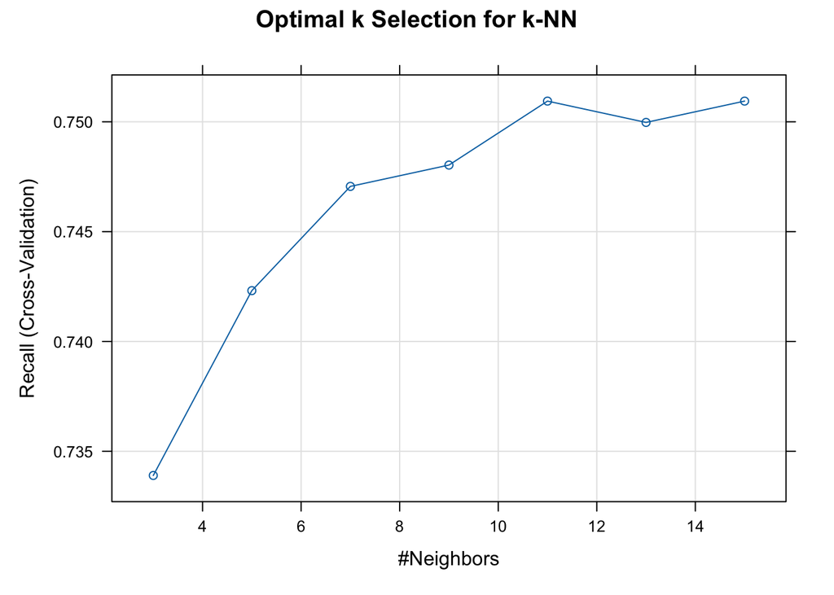

```r
plot(knnFit, main = "Optimal k Selection for k-NN")
```

#### Confusion Matrix

To evaluate the performance of the k-NN model, we analyze the confusion matrix.

```r
# Prediction
predicted_probs_knn <- predict(knnFit, newdata = test_scaled, type = "prob")[, "Yes"]
predicted_knn <- ifelse(predicted_probs_knn > 0.5, "Yes", "No")

predicted_knn <- factor(predicted_knn, levels = c("No", "Yes"))
actual <- factor(test_scaled$Depression, levels = c("No", "Yes"))

# Confusion matrix
conf_matrix_knn <- confusionMatrix(predicted_knn, actual)

# Extract metrics from confusionMatrix
knn_accuracy <- conf_matrix_knn$overall["Accuracy"]
knn_precision <- conf_matrix_knn$byClass["Pos Pred Value"]
knn_recall <- conf_matrix_knn$byClass["Sensitivity"]
knn_f1 <- conf_matrix_knn$byClass["F1"]

knn_metrics2 <- data.frame(
  Model = "k-NN",
  Accuracy = knn_accuracy,
  Precision = knn_precision,
  Recall = knn_recall,
  F1_Score = knn_f1
)

print(knn_metrics2)
```

```
##          Model  Accuracy Precision    Recall  F1_Score
## Accuracy  k-NN 0.8322569  0.822381 0.7544779 0.7869674
```

From the Confusion Matrics for the k-nn performed before, we can make the following statements:

- Accuracy (0.8323): The model correctly classified 83.23% of all instances, indicating solid overall performance.
- Precision (0.8224): Out of all the positive predictions made by the model, 82.24% were correct, demonstrating reasonable control over false positives.
- Recall (0.7545): The model successfully identified 75.45% of actual positive cases.
- F1-Score (0.787): The harmonic mean of Precision and Recall is 78.7%, indicating a good balance between the two metrics.

This performance means the k-NN model is slightly worse at correctly detecting people with depression than the logistic regression.

## 4. Naive Bayes Model

```r
nbFit <- naiveBayes(Depression ~ ., data = trainingdata)
nbFit
```

```
##
## Naive Bayes Classifier for Discrete Predictors
##
## Call:
## naiveBayes.default(x = X, y = Y, laplace = laplace)
##
## A-priori probabilities:
## Y
##        No       Yes
## 0.4158705 0.5841295
##
## Conditional probabilities:
##      Gender
## Y        Female      Male
##   No  0.4456909 0.5543091
##   Yes 0.4444786 0.5555214
##
##      Age
## Y         [,1]     [,2]
##   No  27.16395 4.949745
##   Yes 24.87014 4.673351
##
##      Academic.Pressure
## Y         [,1]     [,2]
##   No  2.355301 1.256081
##   Yes 3.697205 1.188064
##
##      CGPA
## Y         [,1]     [,2]
##   No  7.616958 1.492570
##   Yes 7.681386 1.456439
##
##      Study.Satisfaction
## Y         [,1]     [,2]
##   No  3.203646 1.326500
##   Yes 2.739671 1.351101
##
##      Sleep.Duration
## Y     More than 8 hours    7-8 hours    5-6 hours Less than 5 hours
##   No       0.2544493582 0.2553122640 0.2326609859      0.2567144860
```

[output cut: 15 more lines]

```
##
##      Work.Study.Hours
## Y         [,1]     [,2]
##   No  6.234171 3.865994
##   Yes 7.780986 3.457171
##
##      Financial.Stress
## Y         [,1]     [,2]
##   No  2.512566 1.345747
##   Yes 3.584165 1.334681
##
##      Family.History.of.Mental.Illness
## Y            No       Yes
##   No  0.5464351 0.4535649
##   Yes 0.4950852 0.5049148
```

The A-priori Probability, showing the default likelihood of the two possible outcomes occurring in the training data, are:

#0 (person doesn’t have depression): 41.59 %  
#1 (person has depression): 58.41 %

There are more people with depression in our dataset, than without. Any model must perform better than 58.41% accuracy to be useful (since always predicting “1” would give this level of accuracy).

- **Age**: Depressed individuals are considerably younger (24.87 vs 27.16 years) - Younger age may correlate with higher depression risk.
- **Academic Pressure**: Significantly higher for depressed individuals (3.70 vs 2.36) - High academic pressure can be linked to depression.
- **Suicidal Thoughts**: 85.39% of depressed individuals have had suicidal thoughts and only 32.12% of non-depressed - Those with suicidal thoughts are far more likely to be depressed.
- **Work.Study.Hours**: Depressed individuals work/study more (7.78 vs 6.23).
- **Financial Stress**: Considerably higher for depressed individuals (3.58 vs 2.51) - Financial stress can increase depression risk.
- **Sleep Duration**: “Less than 5 hours” is more common in depressed individuals (32.53% vs 25.67%), while “More than 8 hours” is less common (18.94% vs 25.44%) - Short sleep duration is associated with depression.
- **Dietary Habits**: “Unhealthy” habits are much more common in depressed individuals (44.45% vs 26.06%), while “Healthy” habits are less common (21.59% vs 36.34%)
- **Study Satisfaction** is slightly lower (2.74 vs 3.20) for depressed individuals.
- **Family History of Mental Illness** is a bit more common (50.49% vs 45.36%) in depressed individuals.
- **Gender** and **CGPA** shows practically no difference.

#### Confusion Matrix

To evaluate the performance of the Naive Bayes model, we analyze the confusion matrix.

```r
predicted_probs_nb <- predict(nbFit, newdata = testdata)

# Create confusion matrix
conf_matrix_nb <- confusionMatrix(predicted_probs_nb, testdata$Depression)

# Extract metrics from confusionMatrix
nb_accuracy <- conf_matrix_nb$overall["Accuracy"]
nb_precision <- conf_matrix_nb$byClass["Pos Pred Value"]
nb_recall <- conf_matrix_nb$byClass["Sensitivity"]
nb_f1 <- conf_matrix_nb$byClass["F1"]

nb_metrics2 <- data.frame(
  Model = "Naive Bayes",
  Accuracy = nb_accuracy,
  Precision = nb_precision,
  Recall = nb_recall,
  F1_Score = nb_f1
)

print(nb_metrics2)
```

```
##                Model  Accuracy Precision    Recall F1_Score
## Accuracy Naive Bayes 0.8466093 0.8253176 0.7946702 0.809704
```

- Accuracy (0.8466): The model correctly classified 84.66% of all instances, showcasing stronger overall performance than k-NN model, but weaker compared to logistic regression.
- Precision (0.8253): Out of all positive predictions, 82.53% were accurate, indicating similar situation as with accuracy compared to other models
- Recall (0.7947): The model identified 79.47% of actual positive cases, demonstrating its ability to minimize false negatives. However, the logistic regression model still outperforms in recall.
- F1-Score (0.8097): The harmonic mean of Precision and Recall is 80.97%, reflecting a well-balanced performance between identifying positive cases and avoiding false positives.

This model’s metrics suggest better performance compared the k-NN model, but a slightly worse one than of the logistic regression.

## 5. Classification Tree Model

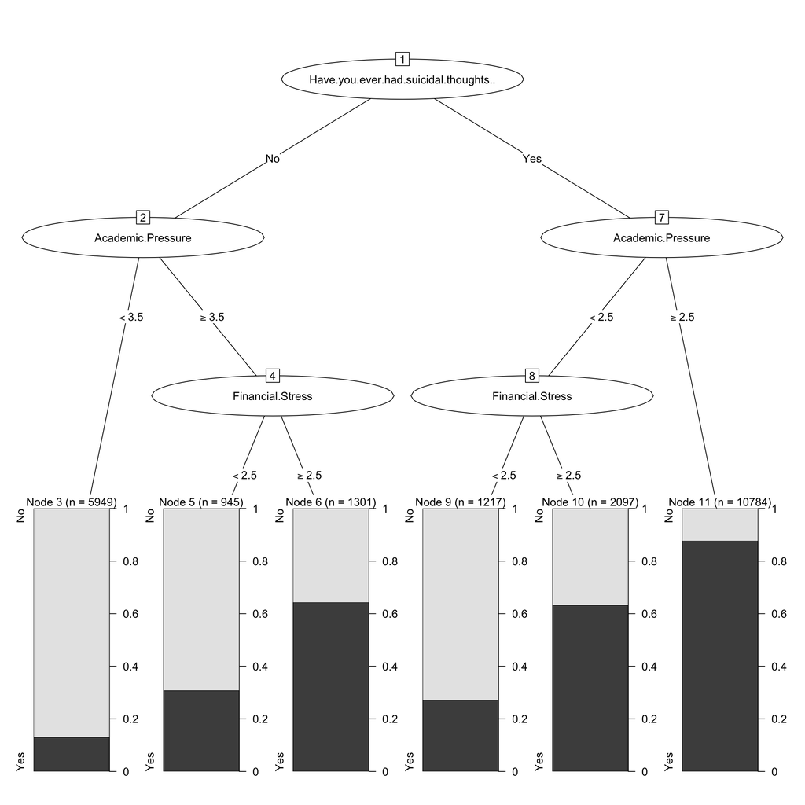

```r
trainingdata$Depression <- factor(trainingdata$Depression)
tree <- rpart(Depression ~ ., data = trainingdata)
plot(as.party(tree))
```

The classification tree analyzes factors related to suicidal thoughts, with the root node asking if someone has experienced suicidal thoughts before branching into different paths. For those who answered “No,” the model evaluates academic pressure using a threshold of 3.5, with those below this level classified into Node 3 (n=5949), while those above this threshold are further assessed based on financial stress. Those who answered “Yes” to suicidal thoughts are evaluated on academic pressure with a lower threshold of 2.5; if their academic pressure is below 2.5, they’re further classified by financial stress, but if it’s 2.5 or higher, they go directly to Node 11, which contains the largest population (n=10784) and displays the highest proportion of risk in its bar graph. The tree suggests that both academic pressure and financial stress are important predictors, with different threshold levels mattering depending on whether someone has already experienced suicidal thoughts, making Node 11 (individuals with suicidal thoughts and academic pressure ≥2.5) the highest risk group.

#### Confusion Matrix

To evaluate the performance of the classification tree model, we analyze the confusion matrix.

```r
predicted_probs_tree <- predict(tree, newdata = testdata, type = "class")
conf_matrix <- confusionMatrix(predicted_probs_tree, testdata$Depression)

# Extract confusion Matrix components
accuracy <- conf_matrix$overall["Accuracy"]
precision <- conf_matrix$byClass["Pos Pred Value"]
recall <- conf_matrix$byClass["Sensitivity"]
f1 <- conf_matrix$byClass["F1"]

# Create metrics dataframe
metrics_tree2 <- data.frame(
  Model = "Classification Tree",
  Accuracy = accuracy,
  Precision = precision,
  Recall = recall,
  F1_Score = f1
)

print(metrics_tree2)
```

```
##                        Model  Accuracy Precision    Recall  F1_Score
## Accuracy Classification Tree 0.8177252 0.8209783 0.7112276 0.7621723
```

From the Confusion Matrics for the classification tree performed before, we can make the following statements:

- Accuracy (81.77%): The model correctly classified approximately 82% of all test instances, making it the worst one at Accuracy so far.
- Precision (82.09%): When the model predicted a positive case , it was correct about 82% of the time, indicating a similar position as with Accuracy compared to other models.
- Recall (71.12%): The model successfully identified about 71% of actual positive cases, showing a much worse performance compared to out other models.
- F1-Score (76.22%): The harmonic mean of precision and recall indicates the same situation as with all the other metrics, when comparing to other models.

Overall, the classification tree model is inferior to all the other models regarding all the metrics.

## 6. Random Forest Model

```r
rf <- ranger(Depression ~ ., data = trainingdata, probability = TRUE, importance = "permutation")
print(rf)
```

```
## Ranger result
##
## Call:
##  ranger(Depression ~ ., data = trainingdata, probability = TRUE,      importance = "permutation")
##
## Type:                             Probability estimation
## Number of trees:                  500
## Sample size:                      22293
## Number of independent variables:  11
## Mtry:                             3
## Target node size:                 10
## Variable importance mode:         permutation
## Splitrule:                        gini
## OOB prediction error (Brier s.):  0.1130589
```

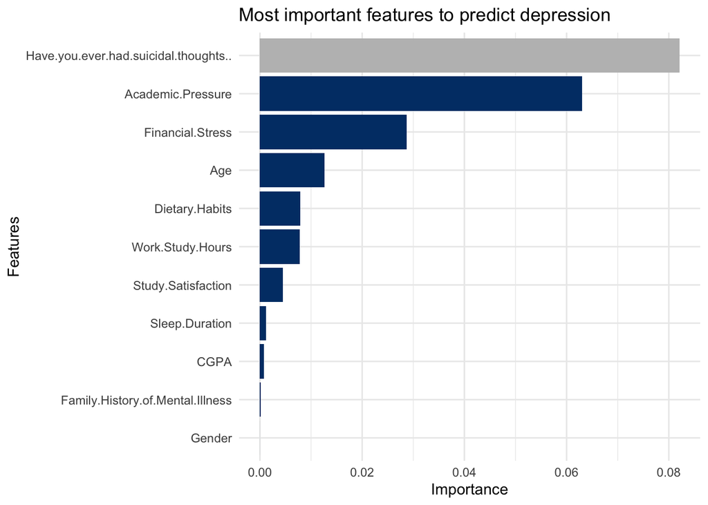

```r
# Get the importance values
importance_values <- importance(rf)

# Create a data_new frame for ggplot
importance_df <- data.frame(Feature = names(importance_values), Importance = importance_values)

# Sort the data_new frame by importance
importance_df <- importance_df[order(importance_df$Importance, decreasing = TRUE), ]

# Create a new column for color based on importance
importance_df$Color <- ifelse(importance_df$Importance == max(importance_df$Importance),
                              "grey", "#003c75")

# Create the plot using ggplot2
ggplot(importance_df, aes(x = reorder(Feature, Importance), y = Importance, fill = Color)) +
  geom_bar(stat = "identity") +
  coord_flip() + # Flip the coordinates for better readability
  labs(x = "Features", y = "Importance", title = "Most important features to predict depression") +
  scale_fill_identity() +  # Use the fill values directly
  theme_minimal() +
  theme(legend.position = "none") # Remove the legend“
```

The most critical predictor is “Have you ever had suicidal thoughts…”, showing the highest importance score, which aligns with common knowledge that suicidal thoughts are strongly linked to depression. Following this, Academic Pressure and Financial Stress emerge as significant contributors, reflecting how environmental stress impacts mental health. Age and Work Study Hours also play notable roles, suggesting younger individuals and those with heavier workloads may be more vulnerable. Lifestyle factors like Dietary Habits, Sleep Duration, and Study Satisfaction appear moderately influential, while CGPA, Family History of Mental Illness, and Gender show relatively lower importance, indicating weaker associations with depression in the model.

#### Partial Dependency Visualisations

Now that we have identified the most important features, we can create visualizations for the top three predictors (suicidal thoughts, academic pressure, and financial stress). This will help us further explore and understand the relationships between these predictors and Depression, providing deeper insights into their impact.

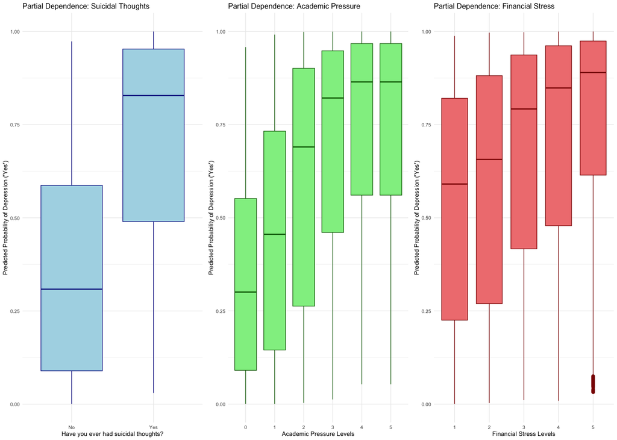

```r
trainingdata$Have.you.ever.had.suicidal.thoughts.. <- as.factor(trainingdata$Have.you.ever.had.suicidal.thoughts..)

grd <- levels(trainingdata$Have.you.ever.had.suicidal.thoughts..)
pdp_data <- data.frame()


for (i in 1:length(grd)) {

  temp_data <- trainingdata
  temp_data$Have.you.ever.had.suicidal.thoughts.. <- factor(grd[i], levels = grd)

  p <- predict(rf, data = temp_data, type = "response")$predictions[, "Yes"]
  pdp_data <- rbind(pdp_data, data.frame(Level = grd[i], Predicted_Probability = p))
}

p1<- ggplot(pdp_data, aes(x = Level, y = Predicted_Probability)) +
  geom_boxplot(fill = "lightblue", color = "darkblue") +
  labs(
    title = "Partial Dependence: Suicidal Thoughts",
    x = "Have you ever had suicidal thoughts?",
    y = "Predicted Probability of Depression ('Yes')"
  ) +
  theme_minimal(base_size = 5)

# Academic Pressure
trainingdata$Academic.Pressure <- as.factor(trainingdata$Academic.Pressure)

grd_academic <- levels(trainingdata$Academic.Pressure)
pdp_data_academic <- data.frame()

for (i in 1:length(grd_academic)) {

  temp_data <- trainingdata
  temp_data$Academic.Pressure <- factor(grd_academic[i], levels = grd_academic)

  p <- predict(rf, data = temp_data, type = "response")$predictions[, "Yes"]
  pdp_data_academic <- rbind(pdp_data_academic, data.frame(Level = grd_academic[i], Predicted_Probability = p))
}

p2<- ggplot(pdp_data_academic, aes(x = Level, y = Predicted_Probability)) +
  geom_boxplot(fill = "lightgreen", color = "darkgreen") +
  labs(
    title = "Partial Dependence: Academic Pressure",
    x = "Academic Pressure Levels",
    y = "Predicted Probability of Depression ('Yes')"
  ) +
  theme_minimal(base_size = 5)


# Financial Stress
trainingdata$Financial.Stress <- as.factor(trainingdata$Financial.Stress)

grd_financial <- levels(trainingdata$Financial.Stress)
pdp_data_financial <- data.frame()

for (i in 1:length(grd_financial)) {

  temp_data <- trainingdata
  temp_data$Financial.Stress <- factor(grd_financial[i], levels = grd_financial)

  p <- predict(rf, data = temp_data, type = "response")$predictions[, "Yes"]
  pdp_data_financial <- rbind(pdp_data_financial, data.frame(Level = grd_financial[i], Predicted_Probability = p))
}

p3 <- ggplot(pdp_data_financial, aes(x = Level, y = Predicted_Probability)) +
  geom_boxplot(fill = "lightcoral", color = "darkred") +
  labs(
    title = "Partial Dependence: Financial Stress",
    x = "Financial Stress Levels",
    y = "Predicted Probability of Depression ('Yes')"
  ) +
  theme_minimal(base_size = 5)

grid.arrange(p1, p2, p3, ncol = 3)
```

1. Partial Dependence: Suicidal Thoughts:

This plot shows how the predicted probability of depression changes based on whether an individual has ever had suicidal thoughts. Individuals who answered “Yes” have a significantly higher predicted probability of depression compared to those who answered “No.”

2. Partial Dependence: Academic Pressure:

This plot illustrates the relationship between academic pressure levels and the predicted probability of depression. As academic pressure increases, the predicted probability of depression generally rises, indicating a positive correlation.

3. Partial Dependence: Financial Stress:

This plot demonstrates how financial stress levels affect the predicted probability of depression. Higher financial stress levels correspond to an increase in the predicted probability of depression, highlighting its strong impact.

#### Confusion Matrix

To evaluate the performance of the random forest model, we analyze the confusion matrix.

```r
# Get predictions
predicted_probs_rf <- predict(rf, data = testdata, type = "response")$predictions
predicted_rf <- ifelse(predicted_probs_rf[,2] > 0.5, "Yes", "No")

# Ensure factors have matching levels
actual <- factor(testdata$Depression, levels = c("No", "Yes"))
predicted_rf <- factor(predicted_rf, levels = c("No", "Yes"))

# Using caret for confusion matrix (more robust)
conf_matrix <- confusionMatrix(predicted_rf, actual)

# Extract metrics directly from confusionMatrix
accuracy <- conf_matrix$overall["Accuracy"]
precision <- conf_matrix$byClass["Pos Pred Value"]
recall <- conf_matrix$byClass["Sensitivity"]
f1 <- conf_matrix$byClass["F1"]

metrics_rf2 <- data.frame(
  Model = "Random Forest",
  Accuracy = accuracy,
  Precision = precision,
  Recall = recall,
  F1_Score = f1
)
print(metrics_rf2)
```

```
##                  Model  Accuracy Precision    Recall  F1_Score
## Accuracy Random Forest 0.8448152 0.8215899 0.7946702 0.8079058
```

# Model Evaluation

### Combined Confusion Matrix

```r
all_metrics <- rbind(glm_metrics2, knn_metrics2, nb_metrics2, metrics_tree2, metrics_rf2)
print(all_metrics)
```

```
##                         Model  Accuracy Precision    Recall  F1_Score
## Accuracy       GLM (Stepwise) 0.8471475 0.8258503 0.7955439 0.8104139
## Accuracy1                k-NN 0.8322569 0.8223810 0.7544779 0.7869674
## Accuracy2         Naive Bayes 0.8466093 0.8253176 0.7946702 0.8097040
## Accuracy3 Classification Tree 0.8177252 0.8209783 0.7112276 0.7621723
## Accuracy4       Random Forest 0.8448152 0.8215899 0.7946702 0.8079058
```

From the combined confusion matrix we can see the following results:

- GLM (Stepwise): Shows the best overall balance, with the highest accuracy and strong recall, making it a top candidate.
- k-NN: Lower recall compared to GLM, indicating more false negatives; less suitable when recall is prioritized.
- Naive Bayes: Very comparable to GLM in all metrics, with nearly identical recall. A solid alternative.
- Classification Tree: Lowest recall among all models, indicating it misses more actual positive cases; not ideal for this project.
- Random Forest: Competitive performance and good recall, though slightly behind GLM and Naive Bayes.

Overall, the GLM (Stepwise) model achieved the best combination of metrics, particularly in recall (0.7955), making it the most suitable choice for this project. Naive Bayes and Random Forest also performed well and can be considered as backup models. Models like k-NN and Classification Tree are less favorable due to their lower recall.

### 10 Fold Cross-Validation

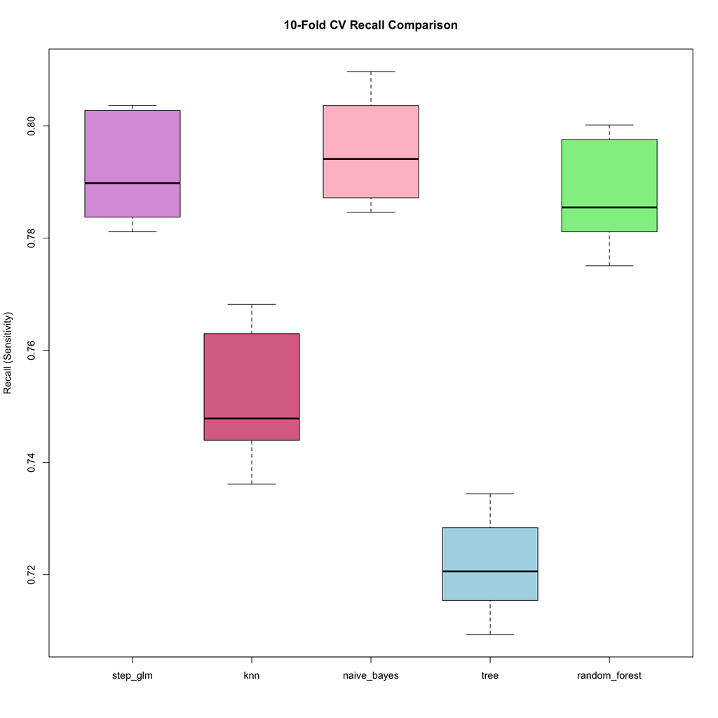

```r
# Data Preprocessing
data_n$Financial.Stress <- as.numeric(data_n$Financial.Stress)

# 10 folds for cross-validation
set.seed(123)
folds <- createFolds(data_n$Depression, k = 10, list = TRUE, returnTrain = TRUE)

# Creating the placeholders for results
recall_scores <- data.frame(step_glm = numeric(), knn = numeric(), naive_bayes = numeric(), tree = numeric(), random_forest = numeric())

# Scaling numeric variables once for all folds
numeric_cols <- sapply(data_n, is.numeric)
data_new_scaled <- data_n
data_new_scaled[, numeric_cols] <- lapply(data_n[, numeric_cols], scale)

for (fold_index in 1:10) {

  # Here we are splitting data into training and test sets
  train_indices <- folds[[fold_index]]
  training_data <- data_new_scaled[train_indices, ]
  test_data <- data_new_scaled[-train_indices, ]

  # Stepwise Logistic Regression (as it has lower AIC compared to Logistic)
  base_model <- glm(Depression ~ ., data = training_data, family = "binomial")
  step_model <- step(base_model, direction = "both", trace = 0)  # Use stepwise selection
  step_predictions <- predict(step_model, newdata = test_data, type = "response")
  step_pred_class <- ifelse(step_predictions > 0.5, "Yes", "No")
  step_conf_matrix <- confusionMatrix(factor(step_pred_class, levels = c("No", "Yes")),
                                      test_data$Depression)

  # k-NN Model
  knn_model <- train(Depression ~ ., data = training_data,
                     method = "knn",
                     trControl = trainControl(method = "none"),
                     tuneGrid = data.frame(k = 15),
                     metric = "Recall")
  knn_predictions <- predict(knn_model, newdata = test_data)
  knn_conf_matrix <- confusionMatrix(knn_predictions, test_data$Depression)

  # Naive Bayes
  nb_model <- naiveBayes(Depression ~ ., data = training_data)
  nb_predictions <- predict(nb_model, newdata = test_data)
  nb_conf_matrix <- confusionMatrix(nb_predictions, test_data$Depression)

  # Decision Trees
  tree_model <- rpart(Depression ~ ., data = training_data)
  tree_predictions <- predict(tree_model, newdata = test_data, type = "class")
  tree_conf_matrix <- confusionMatrix(tree_predictions, test_data$Depression)

  # Random Forest
  rf_model <- ranger(Depression ~ ., data = training_data, probability = TRUE, importance = "permutation")
  rf_predictions <- predict(rf_model, data = test_data)$predictions
  rf_pred_class <- ifelse(rf_predictions[, 2] > 0.5, "Yes", "No")
  rf_conf_matrix <- confusionMatrix(factor(rf_pred_class, levels = c("No", "Yes")),
                                    test_data$Depression)


  recall_scores <- rbind(recall_scores, data.frame(
    step_glm = step_conf_matrix$byClass["Recall"],
    knn = knn_conf_matrix$byClass["Recall"],
    naive_bayes = nb_conf_matrix$byClass["Recall"],
    tree = tree_conf_matrix$byClass["Recall"],
    random_forest = rf_conf_matrix$byClass["Recall"]
  ))
}


boxplot(recall_scores,
        ylab = "Recall (Sensitivity)",
        col = c('plum', 'palevioletred', 'pink', 'lightblue', 'lightgreen'),
        main = "10-Fold CV Recall Comparison")
```

From the 10-Fold CV Recall Comparison, we can observe that Naive Bayes and step-wise GLM have the highest median recall scores, both around 0.79–0.80, indicating they are most effective at capturing true positives. Random forest also performs well, with a slightly lower median recall near 0.78. KNN has a moderate recall (around 0.75), while the decision tree model has the lowest recall, with a median near 0.72. Overall, naive Bayes and step-wise GLM outperform the other models in terms of recall, while the decision tree lags behind.

# Future Work

This project has provided important insights into the factors associated with depression among students, along with predictive models to identify individuals at risk. However, there are several areas where further research and development can enhance the outcomes. One key area for future work is the incorporation of longitudinal data, which would allow for the study of how depression risk factors change over time, offering a deeper understanding of causal relationships. Expanding the dataset to include individuals from a wider range of geographic, cultural, and socioeconomic backgrounds would also improve the generalizability of the findings.

Additionally, including new variables, such as social media usage, physical activity levels, and access to mental health resources, could make the models more comprehensive. Another promising area is the development of real-time prediction systems that integrate with wearable devices or mobile applications to monitor lifestyle factors like sleep patterns and activity levels, enabling early interventions.

Collaboration with mental health professionals is another important step, as their expertise can help interpret the findings and design effective, tailored interventions for individuals at risk. Ethical considerations, such as addressing privacy concerns and algorithmic bias, must also be prioritized to ensure the responsible use of predictive models. Finally, testing the models in real-world settings, such as schools, workplaces, and healthcare facilities, would provide valuable insights into their practical utility and effectiveness. By focusing on these areas, future work can build upon this project to create more robust and impactful tools for addressing mental health challenges.

# Conclusions

In conclusion, this project has helped us understand the important factors that contribute to depression among students and young professionals. We found that things like sleep habits, diet, work hours, and personal background can all affect someone’s risk of depression, but the main influential factors are still suicidal thoughts, academic pressure, and financial stress. Both through 10-fold cross-validation and out-of-sample performance, we observed that the Naive Bayes and stepwise GLM models had the highest recall, meaning they were most effective at correctly identifying individuals at risk of depression. By focusing on prediction rather than inference, the project offers practical tools that stakeholders can use to address mental health challenges effectively.

For educational institutions, the insights gained from this study can guide the development of policies aimed at reducing academic stress and promoting mental well-being among students. Workplace stakeholders, including employers and human resource managers, can leverage these findings to create healthier work environments, such as balancing workloads and encouraging better work-life integration. Healthcare professionals and policymakers can also use the predictive models to develop early warning systems, enabling timely interventions for individuals at risk.

The implications of this work highlight the importance of integrating data-driven approaches into mental health strategies. By identifying at-risk individuals early, stakeholders can implement targeted interventions that not only improve individual well-being but also contribute to healthier, more productive communities. The findings underline the urgent need for collaborative efforts among educators, employers, healthcare providers, and policymakers to address the growing mental health challenges faced by young populations. So, we hope that our project provides a foundation for these efforts, paving the way for future advancements in mental health research and practice.